# post02-lindsay-dahlen

## 7. Grouping in ggvis

Let’s try one more example, this time by looking at grouping. To group, use the function “group_by”

```r
iris %>% ggvis(~Sepal.Length, ~Sepal.Width, stroke = ~Species) %>%
  layer_points() %>%
  group_by(Species) %>%
  layer_paths()
```

[output not shown]

## 8. ggplot2 vs. ggvis

Using ggvis is very similar to using ggplot2. There are some notable distinctions, which I will summarize a few of them as follows.

- Faceting is not supported in ggvis. Even when it it, it does not resember faceting in ggplot2.
- ggplot2 syntax makes a distinction between mapping variables and setting constants. In ggvis, everything is a property.
- ggvis has black outlines by default.
- It is not possible to incorrectly mapp an aesthetic to a scalar.

Let’s compare ggplot with ggvis, by looking at a default histograms of petal lengths.

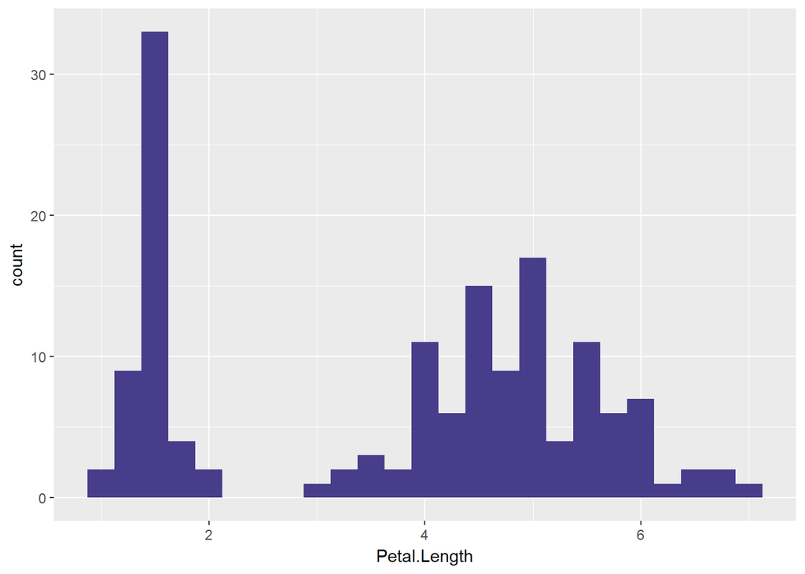

```r
## ggplot2
ggplot(iris, aes(x=Petal.Length)) + geom_histogram(binwidth=.25, fill="darkslateblue")
```

```r
##ggvis
iris %>% ggvis(~Petal.Length) %>% layer_histograms(width=.25, fill:="darkslateblue")
```

## 9. Conclusion

ggvis is a very useful package for visualizing data and can be used with shiny apps. It is a newer package, and as such it cannot do all the same functions that ggplot2 can do. Fortunately, the developers are continuing to bring ggvis up to the same level as ggplot2. This is especially nice as ggvis has several default parameters that make it more efficient. Overall, I like the look of ggvis better and I think the coding is easy to learn.

## 10. References

- https://stat.ethz.ch/R-manual/R-devel/library/datasets/html/iris.html
- https://ggvis.rstudio.com/
- https://cran.r-project.org/web/packages/ggvis/README.html
- http://ggvis.rstudio.com/ggplot2.html
- http://jimhester.github.io/ggplot2ToGgvis/
- https://ggvis.rstudio.com/ggvis-basics.html
- http://ggvis.rstudio.com/0.1/properties-scales.html